# Geospatial Risk Prediction

Ling Chen

10/19/2023

# 1 Introduction

As new predictive policing tools come out, it’s critical to provide sufficient contexts for geospatial risk models and take generalizability into consideration. In this project, I’ll look into a generalizable geospatial risk prediction model which foucus on crime. Specifically, I select the city of Chicago as the study area to further analyze the current gun violence in the city, and try to predict gun violence based on some variables which might affect the emergence of gun violence through the geospatial risk model.

# 2 Data Wrangling

## 2.1 Loading Chicago Data

In first section, I load the gun violence data as well as some boundaries of Chicago, including police districts, police beat boundaries, and the city boundary.

## 2.2 Visualizing Gun Violence in Chicago

By plotting point data and density, we can identify the basic pattern of gun violence in Chicago, which is concentrated in the west and middle-south part, the areas where the majority of non-white population live.

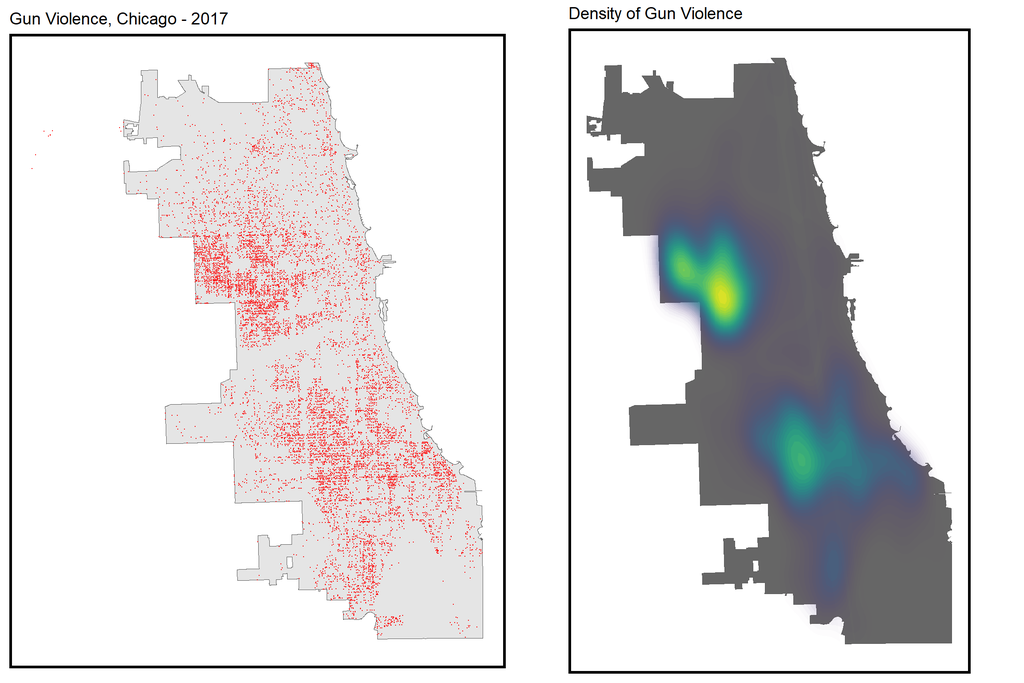

```r
# uses grid.arrange to organize independent plots
grid.arrange(ncol=2,
ggplot() +
  geom_sf(data = chicagoBoundary) +
  geom_sf(data = GunViolence, colour="red", size=0.01, show.legend = "point") +
  labs(title= "Gun Violence, Chicago - 2017") +
  mapTheme(title_size = 14),

ggplot() +
  geom_sf(data = chicagoBoundary, fill = "grey40") +
  stat_density2d(data = data.frame(st_coordinates(GunViolence)),
                 aes(X, Y, fill =after_stat(level), alpha = after_stat(level)),
                 size = 0.01, bins = 40, geom = 'polygon') +
  scale_fill_viridis() +
  scale_alpha(range = c(0.00, 0.35), guide = FALSE) +
  labs(title = "Density of Gun Violence") +
  mapTheme(title_size = 14) + theme(legend.position = "none"))
```

## 2.3 Creating a fishnet

```r
## using {sf} to create the grid
## Note the `.[chicagoBoundary] %>% ` line. This is needed to clip the grid to our data
fishnet <-
  st_make_grid(chicagoBoundary,
               cellsize = 500,
               square = TRUE) %>%
  .[chicagoBoundary] %>%            # fast way to select intersecting polygons
  st_sf() %>%
  mutate(uniqueID = 1:n())
```

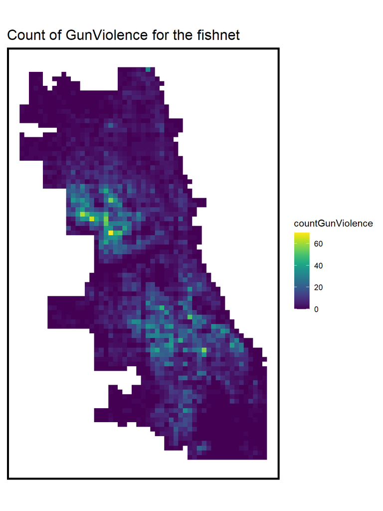

```r
## add a value of 1 to each crime, sum them with aggregate
crime_net <-
  dplyr::select(GunViolence) %>%
  mutate(countGunViolence = 1) %>%
  aggregate(., fishnet, sum) %>%
  mutate(countGunViolence = replace_na(countGunViolence, 0),
         uniqueID = 1:n(),
         cvID = sample(round(nrow(fishnet) / 24),
                       size=nrow(fishnet), replace = TRUE))

ggplot() +
  geom_sf(data = crime_net, aes(fill = countGunViolence), color = NA) +
  scale_fill_viridis() +
  labs(title = "Count of GunViolence for the fishnet") +
  mapTheme()
```

```r
# For demo. requires updated mapview package
# xx <- mapview::mapview(crime_net, zcol = "countBurglaries")
# yy <- mapview::mapview(mutate(burglaries, ID = seq(1:n())))
# xx + yy
```

# 3 Feature Engineering

## 3.1 Modeling Spatial Features

Crime incidents often tend to occur in areas that go unnoticed, typically characterized by dereliction, poor sanitation, disrepair, inadequate lighting, and lax governance. Gun violence, in most cases, is concentrated on streets and in open spaces. To understand and model these patterns, I have selected eight risk factors related to the physical environment. These factors include 311 reports of abandoned cars, malfunctioning street lights, graffiti remediation, sanitation complaints, abandoned buildings, potholes, and garbage carts. Additionally, I’ve incorporated a neighborhood polygon layer and the locations of retail stores selling liquor to-go for a comprehensive analysis.

However, the quality and completeness of some of the data above can vary significantly and also change rapidly over time. Therefore, we should also draw attention to the reliability of the data source.

```r
abandonCars <-
  read.socrata("https://data.cityofchicago.org/Service-Requests/311-Service-Requests-Abandoned-Vehicles/3c9v-pnva") %>%
    mutate(year = substr(creation_date,1,4)) %>% filter(year == "2017") %>%
    dplyr::select(Y = latitude, X = longitude) %>%
    na.omit() %>%
    st_as_sf(coords = c("X", "Y"), crs = 4326, agr = "constant") %>%
    st_transform(st_crs(fishnet)) %>%
    mutate(Legend = "Abandoned_Cars")

abandonBuildings <-
  read.socrata("https://data.cityofchicago.org/Service-Requests/311-Service-Requests-Vacant-and-Abandoned-Building/7nii-7srd") %>%
    mutate(year = substr(date_service_request_was_received,1,4)) %>%  filter(year == "2017") %>%
    dplyr::select(Y = latitude, X = longitude) %>%
    na.omit() %>%
    st_as_sf(coords = c("X", "Y"), crs = 4326, agr = "constant") %>%
    st_transform(st_crs(fishnet)) %>%
    mutate(Legend = "Abandoned_Buildings")

graffiti <-
  read.socrata("https://data.cityofchicago.org/Service-Requests/311-Service-Requests-Graffiti-Removal-Historical/hec5-y4x5") %>%
    mutate(year = substr(creation_date,1,4)) %>% filter(year == "2017") %>%
    filter(where_is_the_graffiti_located_ %in% c("Front", "Rear", "Side")) %>%
    dplyr::select(Y = latitude, X = longitude) %>%
    na.omit() %>%
    st_as_sf(coords = c("X", "Y"), crs = 4326, agr = "constant") %>%
    st_transform(st_crs(fishnet)) %>%
    mutate(Legend = "Graffiti")

streetLightsOut <-
  read.socrata("https://data.cityofchicago.org/Service-Requests/311-Service-Requests-Street-Lights-All-Out/zuxi-7xem") %>%
    mutate(year = substr(creation_date,1,4)) %>% filter(year == "2017") %>%
    dplyr::select(Y = latitude, X = longitude) %>%
    na.omit() %>%
    st_as_sf(coords = c("X", "Y"), crs = 4326, agr = "constant") %>%
    st_transform(st_crs(fishnet)) %>%
    mutate(Legend = "Street_Lights_Out")

sanitation <-
  read.socrata("https://data.cityofchicago.org/Service-Requests/311-Service-Requests-Sanitation-Code-Complaints-Hi/me59-5fac") %>%
    mutate(year = substr(creation_date,1,4)) %>% filter(year == "2017") %>%
    dplyr::select(Y = latitude, X = longitude) %>%
    na.omit() %>%
    st_as_sf(coords = c("X", "Y"), crs = 4326, agr = "constant") %>%
    st_transform(st_crs(fishnet)) %>%
    mutate(Legend = "Sanitation")

liquorRetail <-
  read.socrata("https://data.cityofchicago.org/resource/nrmj-3kcf.json") %>%
    filter(business_activity == "Retail Sales of Packaged Liquor") %>%
    dplyr::select(Y = latitude, X = longitude) %>%
    na.omit() %>%
    st_as_sf(coords = c("X", "Y"), crs = 4326, agr = "constant") %>%
    st_transform(st_crs(fishnet)) %>%
    mutate(Legend = "Liquor_Retail")

# selected new features from open data Chicago.
PotHoles <-
  read.socrata("https://data.cityofchicago.org/Service-Requests/311-Service-Requests-Pot-Holes-Reported-No-Duplica/bp3e-nw4d") %>%
  mutate(year = substr(CREATION.DATE,1,4)) %>% filter(year == "2018") %>%
  dplyr::select(Y = LATITUDE, X = LONGITUDE) %>%
  na.omit() %>%
  st_as_sf(coords = c("X", "Y"), crs = 4326, agr = "constant") %>%
  st_transform(st_crs(fishnet)) %>%
  mutate(Legend = "Pot_Holes")

GarbageCarts <-
  read.socrata("https://data.cityofchicago.org/Service-Requests/311-Service-Requests-Garbage-Carts-Historical/9ksk-na4q") %>%
    mutate(year = substr(creation_date,1,4)) %>%
    filter(year == "2018") %>%
    dplyr::select(Y = latitude, X = longitude) %>%
    na.omit() %>%
    st_as_sf(coords = c("X", "Y"), crs = 4326, agr = "constant") %>%
    st_transform(st_crs(fishnet)) %>%
    mutate(Legend = "Garbage_Carts")

neighborhoods <-
  st_read("https://raw.githubusercontent.com/blackmad/neighborhoods/master/chicago.geojson") %>%
  st_transform(st_crs(fishnet))
```

Then, those features are joined in fishnet and visualized spatially.

```r
vars_net <-
  rbind(abandonCars,streetLightsOut,abandonBuildings,
        liquorRetail, graffiti, sanitation,PotHoles,GarbageCarts) %>%
  st_join(., fishnet, join=st_within) %>%
  st_drop_geometry() %>%
  group_by(uniqueID, Legend) %>%
  summarize(count = n()) %>%
  left_join(fishnet, ., by = "uniqueID") %>%
    spread(Legend, count, fill=0) %>%
    st_sf() %>%
    dplyr::select(-`<NA>`) %>%
    na.omit() %>%
    ungroup()
```

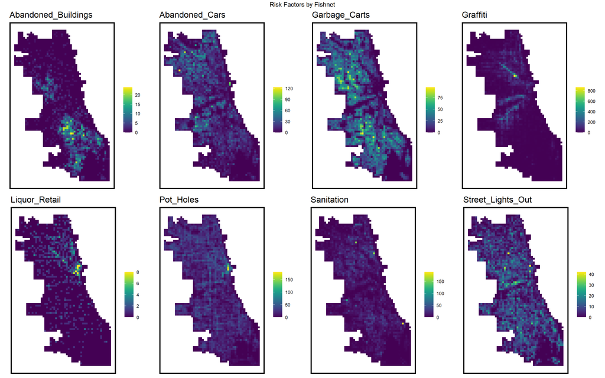

```r
vars_net.long <-
  gather(vars_net, Variable, value, -geometry, -uniqueID)

vars <- unique(vars_net.long$Variable)
mapList <- list()

for(i in vars){
  mapList[[i]] <-
    ggplot() +
      geom_sf(data = filter(vars_net.long, Variable == i), aes(fill=value), colour=NA) +
      scale_fill_viridis(name="") +
      labs(title=i) +
      mapTheme()}

do.call(grid.arrange,c(mapList, ncol=4, top="Risk Factors by Fishnet"))
```

## 3.2 Nearest Neighbor Feature

In this part, I calculate the average nearest neighbor distance to hypothesize a smoother exposure relationship across space. By calculating the average distance from each grid (e.g., abandoned buildings, abandoned cars, graffiti, etc.) to its three nearest neighbors was calculated in order to understand, in a grid format, the distribution patterns of different elements over urban or geographic space. Variations in these distances may help to hypothesize whether risks or events are spatially evenly distributed or whether there is some smooth pattern of association. These results are important predictors in the geospatial risk regression model.

In this section, I compute the average nearest neighbor distance to explore the possibility of a more gradual exposure relationship across spatial areas. This involves calculating the average distance from each grid cell (representing elements like abandoned buildings, abandoned cars, graffiti, etc.) to its three closest neighboring grid cells, which further allows us to examine the distribution patterns of various elements across geographic space in a gridded format. These calculated distances will serve as crucial predictors in the geospatial risk regression model.

```r
# convinience to reduce length of function names.
st_c    <- st_coordinates
st_coid <- st_centroid

## create NN from abandoned cars
  vars_net <-  vars_net %>%
    mutate(
      Abandoned_Buildings.nn =
        nn_function(st_c(st_coid(vars_net)), st_c(abandonBuildings),3),
      Abandoned_Cars.nn =
        nn_function(st_c(st_coid(vars_net)), st_c(abandonCars),3),
      Graffiti.nn =
        nn_function(st_c(st_coid(vars_net)), st_c(graffiti),3),
      Liquor_Retail.nn =
        nn_function(st_c(st_coid(vars_net)), st_c(liquorRetail),3),
      Street_Lights_Out.nn =
        nn_function(st_c(st_coid(vars_net)), st_c(streetLightsOut),3),
      Sanitation.nn =
        nn_function(st_c(st_coid(vars_net)), st_c(sanitation),3),
      PotHoles.nn=
        nn_function(st_c(st_coid(vars_net)), st_c(PotHoles),3),
      GarbageCarts.nn=
        nn_function(st_c(st_coid(vars_net)), st_c(PotHoles),3))
```

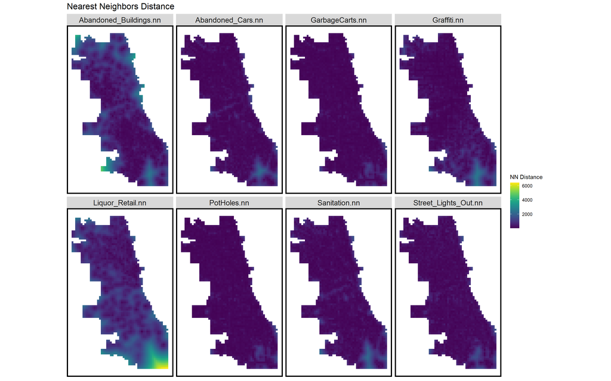

```r
## Visualize the NN feature
vars_net.long.nn <-
  dplyr::select(vars_net, ends_with(".nn")) %>%
    gather(Variable, value, -geometry)

ggplot() +
      geom_sf(data = vars_net.long.nn , aes(fill=value), colour=NA) +
      facet_wrap(~Variable, nrow=2)+
      scale_fill_viridis(name="NN Distance") +
      labs(title="Nearest Neighbors Distance") +
      mapTheme()
```

Then, I join the nearest neighbor features to the fishnet, after which I further join the fishnet to neighborhoods and districts.

```r
## important to drop the geometry from joining features
final_net <-
  left_join(crime_net, st_drop_geometry(vars_net), by="uniqueID")
```

```r
final_net <-
  st_centroid(final_net) %>%
    st_join(dplyr::select(neighborhoods, name), by = "uniqueID") %>%
    st_join(dplyr::select(policeDistricts, District), by = "uniqueID") %>%
      st_drop_geometry() %>%
      left_join(dplyr::select(final_net, geometry, uniqueID)) %>%
      st_sf() %>%
  na.omit()

# for live demo
# mapview::mapview(final_net, zcol = "District")
```

# 4 Exploreing the Spatial Process of Gun Violence

## 4.1 Local Moran’s I Statistics

```r
## generates warnings from PROJ issues
## {spdep} to make polygon to neighborhoods...
final_net.nb <- poly2nb(as_Spatial(final_net), queen=TRUE)
## ... and neighborhoods to list of weigths
final_net.weights <- nb2listw(final_net.nb, style="W", zero.policy=TRUE)

# print(final_net.weights, zero.policy=TRUE)
```

```r
## see ?localmoran
local_morans <- localmoran(final_net$countGunViolence, final_net.weights, zero.policy=TRUE) %>%
  as.data.frame()

# join local Moran's I results to fishnet
final_net.localMorans <-
  cbind(local_morans, as.data.frame(final_net)) %>%
  st_sf() %>%
  dplyr::select(Gun_Violence_Count = countGunViolence,
                Local_Morans_I = Ii,
                P_Value = `Pr(z != E(Ii))`) %>%
  mutate(Significant_Hotspots = ifelse(P_Value <= 0.001, 1, 0)) %>%
  gather(Variable, Value, -geometry)
```

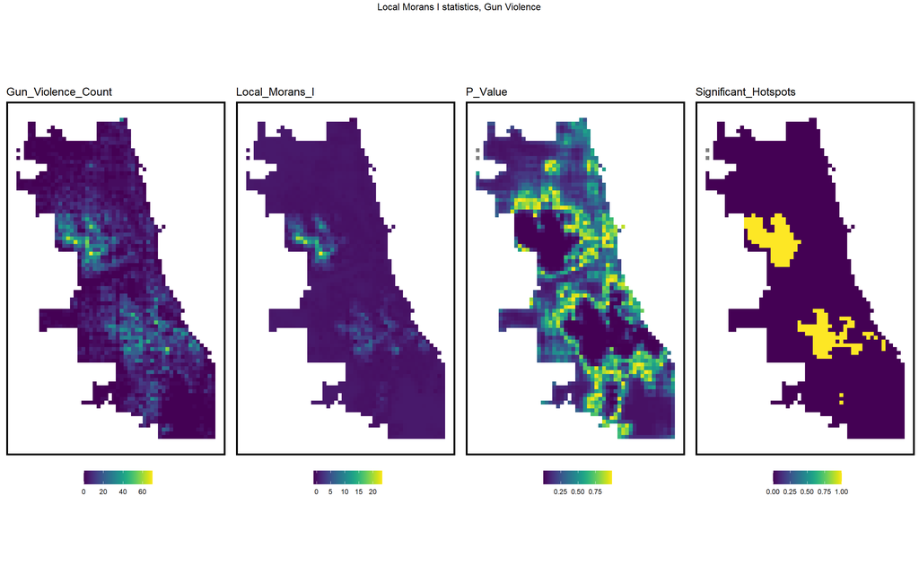

```r
## This is just for plotting
vars <- unique(final_net.localMorans$Variable)
varList <- list()

for(i in vars){
  varList[[i]] <-
    ggplot() +
      geom_sf(data = filter(final_net.localMorans, Variable == i),
              aes(fill = Value), colour=NA) +
      scale_fill_viridis(name="") +
      labs(title=i) +
      mapTheme(title_size = 14) + theme(legend.position="bottom")}

do.call(grid.arrange,c(varList, ncol = 4, top = "Local Morans I statistics, Gun Violence"))
```

## 4.2 Distance to Hot spot

Then I measure average nearest neighbor distance from each cell centroid to its nearest significant cluster(hot spot location).

```r
# generates warning from NN
final_net <- final_net %>%
  mutate(GunViolence.isSig =
           ifelse(local_morans[,5] <= 0.001, 1, 0)) %>%
  mutate(GunViolence.isSig.dist =
           nn_function(st_c(st_coid(final_net)),
                       st_c(st_coid(filter(final_net,
                                           GunViolence.isSig == 1))),
                       k = 1))

## What does k = 1 represent?
```

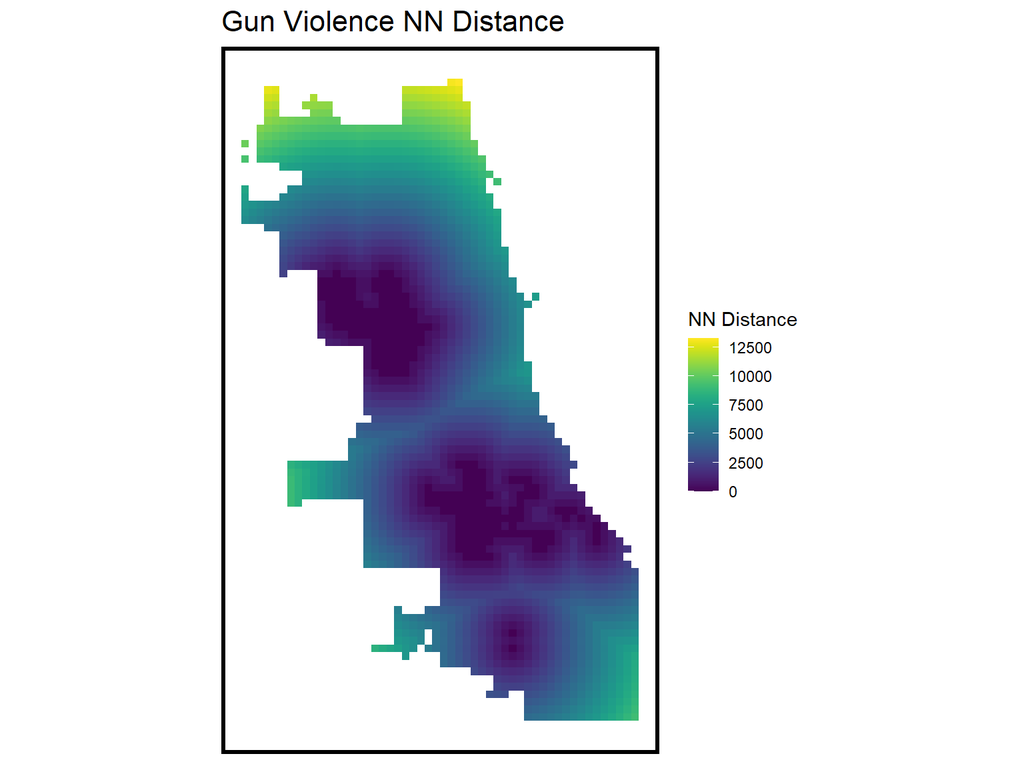

```r
ggplot() +
      geom_sf(data = final_net, aes(fill=GunViolence.isSig.dist), colour=NA) +
      scale_fill_viridis(name="NN Distance") +
      labs(title="Gun Violence NN Distance") +
      mapTheme()
```

## 4.3 Correlation Tests

Based on the Pearson R correlation analysis, most variables exhibit a positive correlation with gun violence. However, there are exceptions such as graffiti (r=0.03), liquor retail (r=0.1), potholes (r=0.13), and abandoned cars (r=0.15), which have a near-zero or weak positive correlation. In contrast, when evaluating the nearest neighbor distance of these variables, all demonstrate a negative relationship with gun violence.

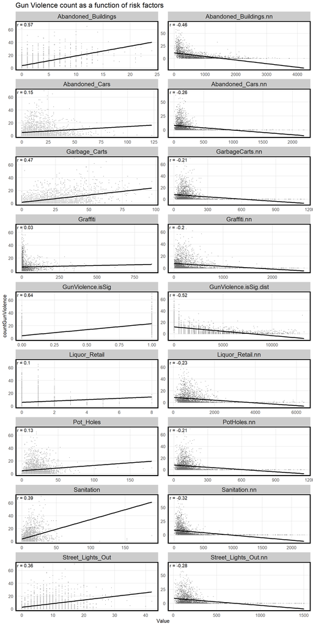

```r
correlation.long <-
  st_drop_geometry(final_net) %>%
    dplyr::select(-uniqueID, -cvID, -name, -District) %>%
    gather(Variable, Value, -countGunViolence)

correlation.cor <-
  correlation.long %>%
    group_by(Variable) %>%
    summarize(correlation = cor(Value, countGunViolence, use = "complete.obs"))

ggplot(correlation.long, aes(Value, countGunViolence)) +
  geom_point(size = 0.1) +
  geom_text(data = correlation.cor, aes(label = paste("r =", round(correlation, 2))),
            x=-Inf, y=Inf, vjust = 1.5, hjust = -.1) +
  geom_smooth(method = "lm", se = FALSE, colour = "black") +
  facet_wrap(~Variable, ncol = 2, scales = "free") +
  labs(title = "Gun Violence count as a function of risk factors") +
  plotTheme()
```

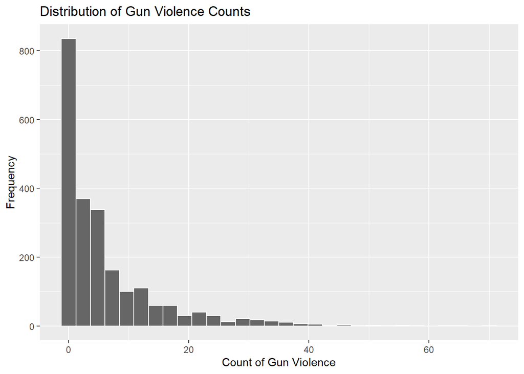

```r
ggplot(final_net, aes(x = countGunViolence)) +
  geom_histogram(fill = "gray40",color ="white") +
  labs(title = "Distribution of Gun Violence Counts",
       x = "Count of Gun Violence",
       y = "Frequency")
```

# 5 Poisson Regression

Prepare for the regression: The first variable list contains only basic spatial features, and the second take significant hotspots of gun violence into consideration.

```r
# View(crossValidate)

## define the variables we want

reg.vars <- c("Abandoned_Buildings.nn", "Abandoned_Cars.nn", "Graffiti.nn",
              "Liquor_Retail.nn", "Street_Lights_Out.nn", "Sanitation.nn",
              "PotHoles.nn")

reg.ss.vars <- c("Abandoned_Buildings.nn", "Abandoned_Cars.nn", "Graffiti.nn",
              "Liquor_Retail.nn", "Street_Lights_Out.nn", "Sanitation.nn",
              "PotHoles.nn", "GarbageCarts.nn","GunViolence.isSig.dist")
```

## 5.1 Cross Validated Poisson Regression

```r
reg.cv <- crossValidate(
  dataset = final_net,
  id = "cvID",
  dependentVariable = "countGunViolence",
  indVariables = reg.vars) %>%
    dplyr::select(cvID = cvID, countGunViolence, Prediction, geometry)
```

[output not shown]

[output cut: 47 more lines]

[output not shown]

```r
reg.ss.cv <- crossValidate(
  dataset = final_net,
  id = "cvID",
  dependentVariable = "countGunViolence",
  indVariables = reg.ss.vars) %>%
    dplyr::select(cvID = cvID, countGunViolence, Prediction, geometry)
```

[output not shown]

[output cut: 47 more lines]

[output not shown]

```r
reg.spatialCV <- crossValidate(
  dataset = final_net,
  id = "name",
  dependentVariable = "countGunViolence",
  indVariables = reg.vars) %>%
    dplyr::select(cvID = name, countGunViolence, Prediction, geometry)
```

[output not shown]

[output cut: 41 more lines]

[output not shown]

```r
reg.ss.spatialCV <- crossValidate(
  dataset = final_net,
  id = "name",
  dependentVariable = "countGunViolence",
  indVariables = reg.ss.vars) %>%
    dplyr::select(cvID = name, countGunViolence, Prediction, geometry)
```

[output not shown]

[output cut: 41 more lines]

[output not shown]

## 5.2 Accuracy & Generalizability

```r
reg.summary <-
  rbind(
    mutate(reg.cv,           Error = Prediction - countGunViolence,
                             Regression = "Random k-fold CV: Just Risk Factors"),

    mutate(reg.ss.cv,        Error = Prediction - countGunViolence,
                             Regression = "Random k-fold CV: Spatial Process"),

    mutate(reg.spatialCV,    Error = Prediction - countGunViolence,
                             Regression = "Spatial LOGO-CV: Just Risk Factors"),

    mutate(reg.ss.spatialCV, Error = Prediction - countGunViolence,
                             Regression = "Spatial LOGO-CV: Spatial Process")) %>%
    st_sf()
```

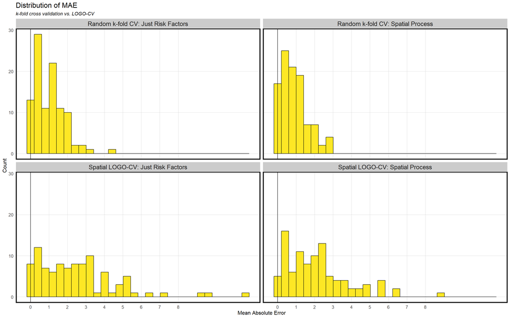

```r
error_by_reg_and_fold <-
  reg.summary %>%
  group_by(Regression, cvID) %>%
  summarize(Mean_Error = mean(Prediction - countGunViolence, na.rm = T),
            MAE = mean(abs(Mean_Error), na.rm = T),
            SD_MAE =sd(Prediction - countGunViolence, na.rm = T)) %>%
  ungroup()

error_by_reg_and_fold %>%
  ggplot(aes(MAE)) +
  geom_histogram(bins = 30, colour="black", fill = "#FDE725FF") +
  facet_wrap(~Regression) +
  geom_vline(xintercept = 0) + scale_x_continuous(breaks = seq(0, 8, by = 1)) +
  labs(title="Distribution of MAE", subtitle = "k-fold cross validation vs. LOGO-CV",
       x="Mean Absolute Error", y="Count") +
  plotTheme()
```

The table below confirms our conclusion that the Spatial Process features improve the model. Comparatively, random k-fold has a better accuracy than spatial LOGO model. And the maps further visualize where the higher errors occur when the local spatial process is not accounted for. Not surprisingly, the largest errors are in the hotspot locations.

```r
st_drop_geometry(error_by_reg_and_fold) %>%
  group_by(Regression) %>%
    summarize(Mean_MAE = round(mean(MAE), 2),
              SD_MAE = round(sd(MAE), 2)) %>%
  kable() %>%
    kable_styling("striped", full_width = F) %>%
    row_spec(2, color = "black", background = "#FDE725FF") %>%
    row_spec(4, color = "black", background = "#FDE725FF")
```

| Regression | Mean_MAE | SD_MAE |
| --- | --- | --- |
| Random k-fold CV: Just Risk Factors | 1.02 | 0.81 |
| Random k-fold CV: Spatial Process | 0.89 | 0.71 |
| Spatial LOGO-CV: Just Risk Factors | 2.52 | 2.17 |
| Spatial LOGO-CV: Spatial Process | 2.15 | 1.70 |

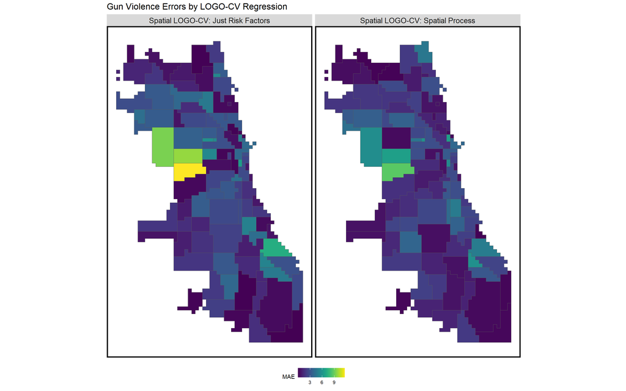

```r
error_by_reg_and_fold %>%
  filter(str_detect(Regression, "LOGO")) %>%
  ggplot() +
    geom_sf(aes(fill = MAE)) +
    facet_wrap(~Regression) +
    scale_fill_viridis() +
    labs(title = "Gun Violence Errors by LOGO-CV Regression") +
    mapTheme() + theme(legend.position="bottom")
```

## 5.3 Generalizability by Neighborhood Context

Further, race data by Census tract is imported to divide the region into majority white and majority non white and test the generalizability. Based on the results, it is evident that the model tends to underestimate the values in Majority_Non_White neighborhoods on average, while overestimating values in Majority_White neighborhoods. The Spatial Process model not only exhibits lower errors overall but also demonstrates a smaller disparity in errors across different neighborhood contexts.

```r
tracts18 <-
  get_acs(geography = "tract", variables = c("B01001_001E","B01001A_001E"),
          year = 2018, state=17, county=031, geometry=T) %>%
  st_transform('ESRI:102271')  %>%
  dplyr::select(variable, estimate, GEOID) %>%
  spread(variable, estimate) %>%
  rename(TotalPop = B01001_001,
         NumberWhites = B01001A_001) %>%
  mutate(percentWhite = NumberWhites / TotalPop,
         raceContext = ifelse(percentWhite > .5, "Majority_White", "Majority_Non_White")) %>%
  .[neighborhoods,]
```

```r
reg.summary %>%
  filter(str_detect(Regression, "LOGO")) %>%
  st_centroid() %>%
  st_join(tracts18) %>%
  na.omit() %>%
  st_drop_geometry() %>%
  group_by(Regression, raceContext) %>%
  summarize(mean.Error = mean(Error, na.rm = T)) %>%
  spread(raceContext, mean.Error) %>%
  kable(caption = "Mean Error by neighborhood racial context(spatial cross validation regression)") %>%
  kable_styling("striped", full_width = F)
```

Mean Error by neighborhood racial context(spatial cross validation regression)

| Regression | Majority_Non_White | Majority_White |
| --- | --- | --- |
| Spatial LOGO-CV: Just Risk Factors | -1.2269386 | 1.2950664 |
| Spatial LOGO-CV: Spatial Process | -0.6449861 | 0.6484019 |

```r
reg.summary %>%
  filter(str_detect(Regression, "k-fold")) %>%
  st_centroid() %>%
  st_join(tracts18) %>%
  na.omit() %>%
  st_drop_geometry() %>%
  group_by(Regression, raceContext) %>%
  summarize(mean.Error = mean(Error, na.rm = T)) %>%
  spread(raceContext, mean.Error) %>%
  kable(caption = "Mean Error by neighborhood racial context(random k-fold)") %>%
  kable_styling("striped", full_width = F)
```

Mean Error by neighborhood racial context(random k-fold)

| Regression | Majority_Non_White | Majority_White |
| --- | --- | --- |
| Random k-fold CV: Just Risk Factors | -1.1533630 | 1.2634720 |
| Random k-fold CV: Spatial Process | -0.5713985 | 0.6233398 |

## 5.4 Density vs Predictions

The following plot demonstrates the computation of kernel density of the gun violence in 2017 at different search radii. The region of higher kernel density is the hotspot.

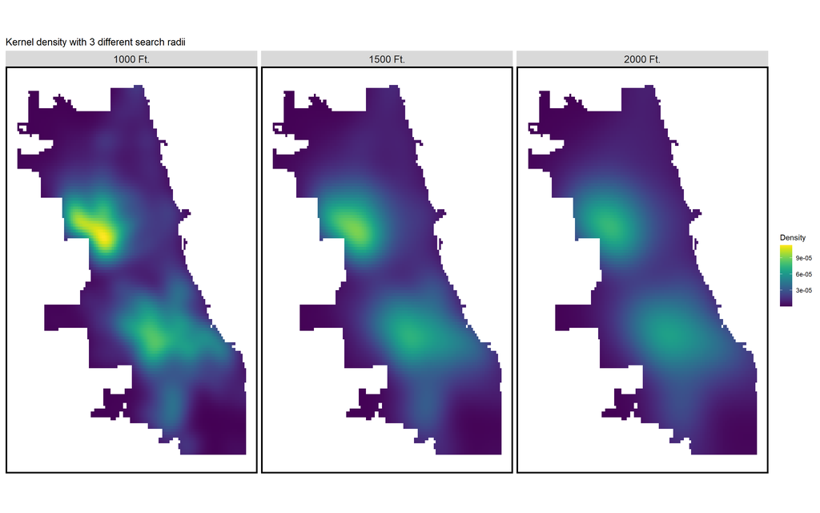

```r
# demo of kernel width
Gun_ppp <- as.ppp(st_coordinates(GunViolence), W = st_bbox(final_net))
Gun_KD.1000 <- spatstat.explore::density.ppp(Gun_ppp, 1000)
Gun_KD.1500 <- spatstat.explore::density.ppp(Gun_ppp, 1500)
Gun_KD.2000 <- spatstat.explore::density.ppp(Gun_ppp, 2000)
Gun_KD.df <- rbind(
  mutate(data.frame(rasterToPoints(mask(raster(Gun_KD.1000), as(neighborhoods, 'Spatial')))), Legend = "1000 Ft."),
  mutate(data.frame(rasterToPoints(mask(raster(Gun_KD.1500), as(neighborhoods, 'Spatial')))), Legend = "1500 Ft."),
  mutate(data.frame(rasterToPoints(mask(raster(Gun_KD.2000), as(neighborhoods, 'Spatial')))), Legend = "2000 Ft."))

Gun_KD.df$Legend <- factor(Gun_KD.df$Legend, levels = c("1000 Ft.", "1500 Ft.", "2000 Ft."))

ggplot(data=Gun_KD.df, aes(x=x, y=y)) +
  geom_raster(aes(fill=layer)) +
  facet_wrap(~Legend) +
  coord_sf(crs=st_crs(final_net)) +
  scale_fill_viridis(name="Density") +
  labs(title = "Kernel density with 3 different search radii") +
  mapTheme(title_size = 14)
```

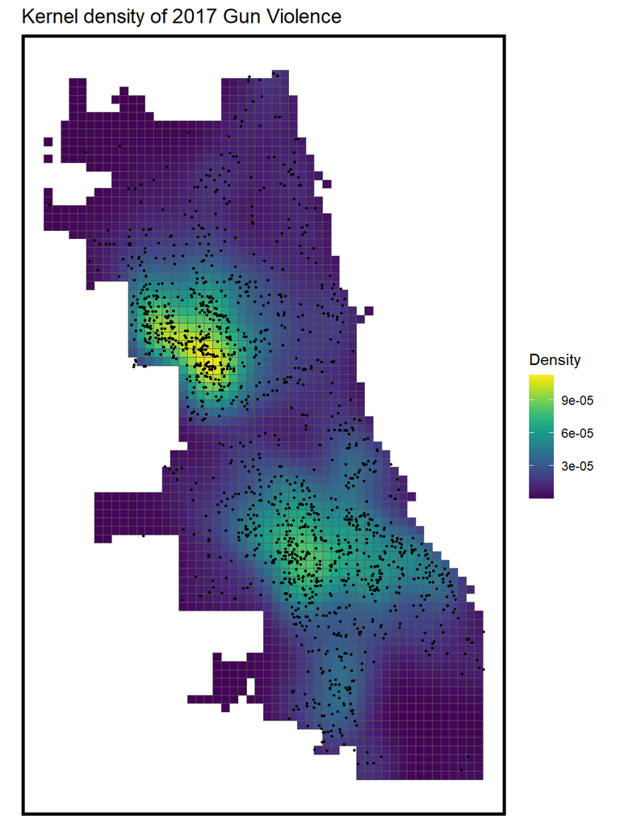

```r
as.data.frame(Gun_KD.1000) %>%
  st_as_sf(coords = c("x", "y"), crs = st_crs(final_net)) %>%
  aggregate(., final_net, mean) %>%
   ggplot() +
     geom_sf(aes(fill=value)) +
     geom_sf(data = sample_n(GunViolence, 1500), size = .5) +
     scale_fill_viridis(name = "Density") +
     labs(title = "Kernel density of 2017 Gun Violence") +
     mapTheme(title_size = 14)
```

```r
GunViolence18 <-
  read.socrata("https://data.cityofchicago.org/Public-Safety/Crimes-2018/3i3m-jwuy") %>%
  filter(str_detect(Description, "HANDGUN")) %>%
        dplyr::select(-Date, -Updated.On) %>%
  mutate(x = gsub("[()]", "", Location)) %>%
  separate(x,into= c("Y","X"), sep=",") %>%
  mutate(X = as.numeric(X),
         Y = as.numeric(Y)) %>%
  na.omit %>%
  st_as_sf(coords = c("X", "Y"), crs = 4326, agr = "constant") %>%
  st_transform('ESRI:102271') %>%
  distinct() %>%
  .[fishnet,]
```

```r
Gun_KDE_sum <- as.data.frame(Gun_KD.1000) %>%
  st_as_sf(coords = c("x", "y"), crs = st_crs(final_net)) %>%
  aggregate(., final_net, mean)
kde_breaks <- classIntervals(Gun_KDE_sum$value,
                             n = 5, "fisher")
Gun_KDE_sf <- Gun_KDE_sum %>%
  mutate(label = "Kernel Density",
         Risk_Category = classInt::findCols(kde_breaks),
         Risk_Category = case_when(
           Risk_Category == 5 ~ "5th",
           Risk_Category == 4 ~ "4th",
           Risk_Category == 3 ~ "3rd",
           Risk_Category == 2 ~ "2nd",
           Risk_Category == 1 ~ "1st")) %>%
  cbind(
    aggregate(
      dplyr::select(GunViolence18) %>% mutate(countGunViolence = 1), ., sum) %>%
    mutate(countGunViolence = replace_na(countGunViolence, 0))) %>%
  dplyr::select(label, Risk_Category, countGunViolence)
```

```r
ml_breaks <- classIntervals(reg.ss.spatialCV$Prediction,
                             n = 5, "fisher")
Gun_risk_sf <-
  reg.ss.spatialCV %>%
  mutate(label = "Risk Predictions",
         Risk_Category =classInt::findCols(ml_breaks),
         Risk_Category = case_when(
           Risk_Category == 5 ~ "5th",
           Risk_Category == 4 ~ "4th",
           Risk_Category == 3 ~ "3rd",
           Risk_Category == 2 ~ "2nd",
           Risk_Category == 1 ~ "1st")) %>%
  cbind(
    aggregate(
      dplyr::select(GunViolence18) %>% mutate(countGunViolence = 1), ., sum) %>%
      mutate(countGunViolence = replace_na(countGunViolence, 0))) %>%
  dplyr::select(label,Risk_Category, countGunViolence)
```

The map is generated of the risk categories for both model types with a sample of gun violence points overlaid. As we can see, the model result matches better with the 2018 gun violence cases. Specifically, the highest risk category is uniquely targeted to places with a high density of gun violence points, indicating that the risk precition model fits well than the kernel density in terms of predictions.

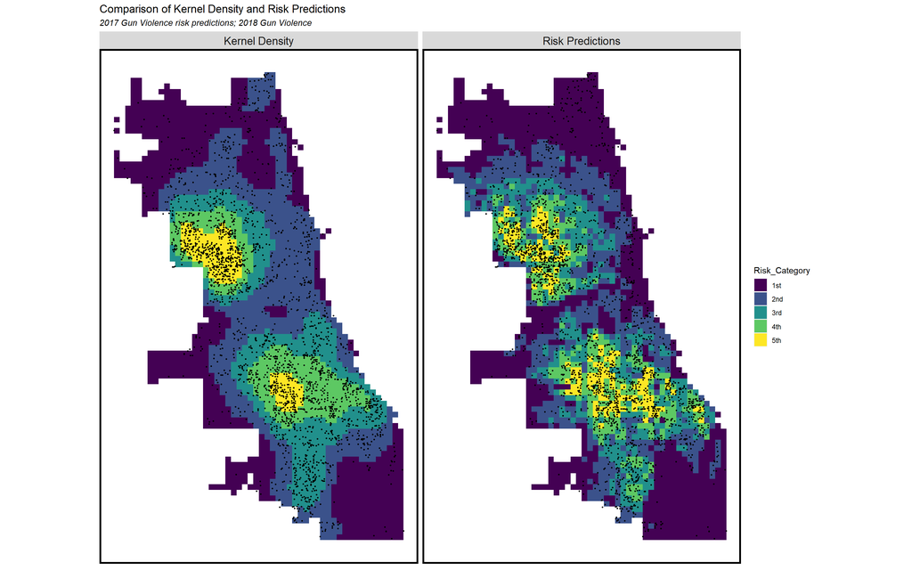

```r
rbind(Gun_KDE_sf, Gun_risk_sf) %>%
  na.omit() %>%
  gather(Variable, Value, -label, -Risk_Category, -geometry) %>%
  ggplot() +
    geom_sf(aes(fill = Risk_Category), colour = NA) +
    geom_sf(data = sample_n(GunViolence18, 3000), size = .5, colour = "black") +
    facet_wrap(~label, ) +
    scale_fill_viridis(discrete = TRUE) +
    labs(title="Comparison of Kernel Density and Risk Predictions",
         subtitle="2017 Gun Violence risk predictions; 2018 Gun Violence") +
    mapTheme(title_size = 14)
```

Finally, I calculate the rate of 2018 gun violence points by risk category and model type. As is clearly shown, the risk predictions capture a greater share of 2018 gun violence in the higher risk category(4th, 5th) relative to the Kernel density.

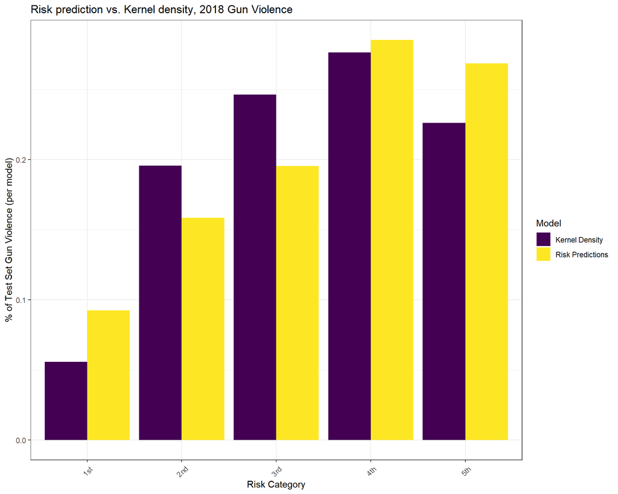

```r
rbind(Gun_KDE_sf, Gun_risk_sf) %>%
  st_drop_geometry() %>%
  na.omit() %>%
  gather(Variable, Value, -label, -Risk_Category) %>%
  group_by(label, Risk_Category) %>%
  summarize(countGunViolence = sum(Value)) %>%
  ungroup() %>%
  group_by(label) %>%
  mutate(Pcnt_of_test_set_crimes = countGunViolence / sum(countGunViolence)) %>%
    ggplot(aes(Risk_Category,Pcnt_of_test_set_crimes)) +
      geom_bar(aes(fill=label), position="dodge", stat="identity") +
      scale_fill_viridis(discrete = TRUE, name = "Model") +
      labs(title = "Risk prediction vs. Kernel density, 2018 Gun Violence",
           y = "% of Test Set Gun Violence (per model)",
           x = "Risk Category") +
  theme_bw() +
      theme(axis.text.x = element_text(angle = 45, vjust = 0.5))
```

# 6 Conclusion

In the project, I developed a generalizable geospatial risk prediction model which foucus on gun violence in the city of Chicago. In the model, I have selected eight risk factors related to the physical environment, which include 311 reports of abandoned cars, malfunctioning street lights, graffiti remediation, sanitation complaints, abandoned buildings, potholes, garbage carts and the locations of retail stores selling liquor to-go for a comprehensive analysis.

However, it’s important to acknowledge some limitations in the model. There is an inherent selection bias in the choice of risk factors, as I may have been influenced by preconceived notions about what elements to include from specific groups or regions. This could result in a potential oversight of other contributing factors not considered. Additionally, the accuracy of the data used for these risk factors is subject to question. It’s crucial to ensure the data used is reliable and up-to-date for the model to provide accurate predictions. Furthermore, the model’s focus on physical environmental factors means it may not account for a comprehensive range of socio-economic elements that could influence gun violence. Future improvements to the model could involve incorporating a broader array of socio-economic indicators for a more holistic understanding.